# Tutorial: embedding learning of malignant cell expression using BayesPrism

Tinyi Chu

Note: if you use BayesPrism in published research, please cite:

> Chu, T., Wang, Z., Pe’er, D. Danko, C. G. Cell type and gene expression deconvolution with BayesPrism enables Bayesian integrative analysis across bulk and single-cell RNA sequencing in oncology. Nat Cancer 3, 505–517 (2022). https://doi.org/10.1038/s43018-022-00356-3

# Introduction

BayesPrism contains an optional embedding learning module to identify gene expression patterns that arise commonly among bulk RNA-seq samples after removal of nonmalignant cells infiltrating the tumor. The mathematical formulation is to factor out the observed #bulk-by-#genes matrix to

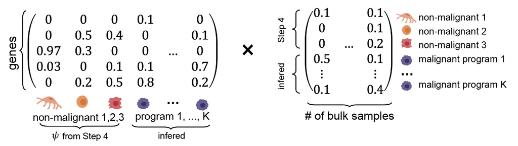

, such that the tumor expression is factored out to multiple malignant gene expression programs.

# Selecting the number of malignant programs K.

Similar to other matrix factorization problems, user needs to specify K. One potential way of selecting K is to scan a range of K values by running non-negative matrix factorizing (NMF) over the (normalized) deconvolved gene expression of malignant cells. K can be chosen by various metrics afterwards.

- Load the BayesPrism package

```r
suppressWarnings(library(BayesPrism))
```

- Load the results from deconvolution

```r
load("bp.res.rdata")
```

- Scan a range of K values (from 2 to 12) using `nmf`. This may take a while.

```r
Z.tum.norm <- t(bp.res@reference.update@psi_mal)
estim.Z.tum.norm <- nmf(Z.tum.norm, rank=2:12, seed=123456)
```

- Visualize various metrics against K.

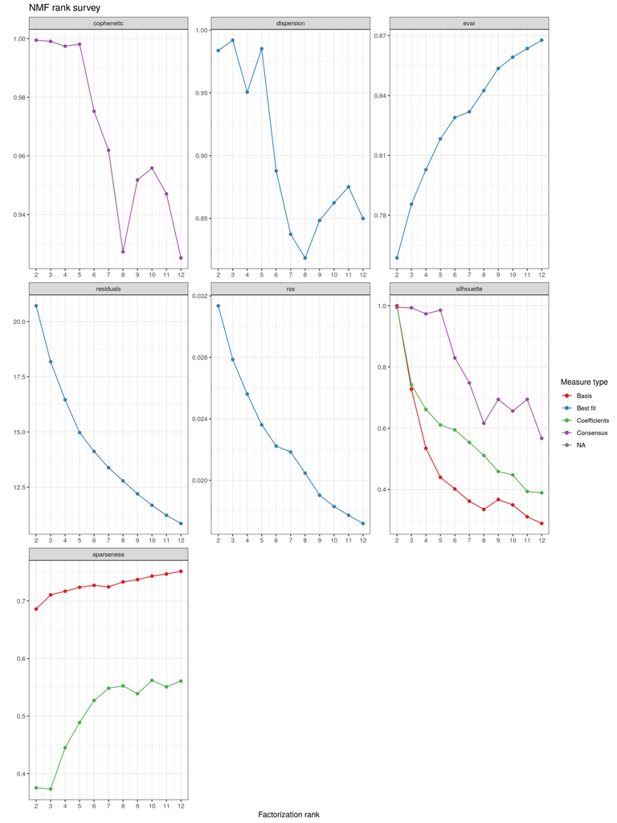

```r
plot(estim.Z.tum.norm)
```

- Plot consensus maps for different K.

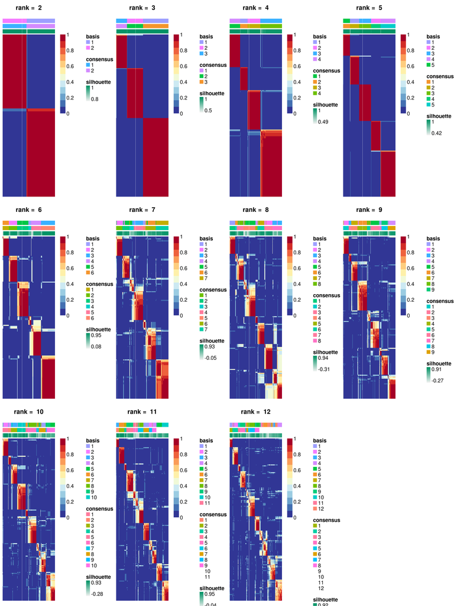

```r
consensusmap(estim.Z.tum.norm, labCol=NA, labRow=NA)
```

- We choose K=5 based on these plots.

# Run embedding learning

```r
# This may take long time to complete...
ebd.res <- learn.embedding.nmf (bp = bp.res, #bp.res needs to be run under the tumor mode.
                                  K = 5,
                                  cycle = 20, #EM typically converges in 50 cycles. set to 20 for demo
                                  compute.elbo = T) #set to TRUE if needs to compute ELBO, otherwise to FALSE which may slightly speed up the computation
```

```
#> NMF algorithm: 'brunet'
#> Multiple runs: 200
#> Mode: parallel (50/72 core(s))
#>
```

```r
Runs: |
Runs: |                                                  |   0%
Runs: |
Runs: |==================================================| 100%
```

[output not shown]

[output cut: 191 more lines]

[output not shown]

- Let’s understand the results

```r
str(ebd.res)
```

```
#> List of 4
#>  $ eta_prior: num [1:5, 1:16145] 6.91e-07 2.16e-06 1.72e-05 4.24e-07 2.61e-06 ...
#>   ..- attr(*, "dimnames")=List of 2
#>   .. ..$ : chr [1:5] "program-1" "program-2" "program-3" "program-4" ...
#>   .. ..$ : chr [1:16145] "ENSG00000130876.10" "ENSG00000165244.6" "ENSG00000173597.7" "ENSG00000158022.6" ...
#>  $ eta_post : num [1:5, 1:16145] 7.88e-07 2.37e-06 1.34e-05 1.11e-07 1.67e-06 ...
#>   ..- attr(*, "dimnames")=List of 2
#>   .. ..$ : chr [1:5] "program-1" "program-2" "program-3" "program-4" ...
#>   .. ..$ : chr [1:16145] "ENSG00000130876.10" "ENSG00000165244.6" "ENSG00000173597.7" "ENSG00000158022.6" ...
#>  $ omega    : num [1:169, 1:5] 0.701906 0.000555 0.324483 0.627062 0.172039 ...
#>   ..- attr(*, "dimnames")=List of 2
#>   .. ..$ : chr [1:169] "TCGA-06-2563-01A-01R-1849-01" "TCGA-06-0749-01A-01R-1849-01" "TCGA-06-5418-01A-01R-1849-01" "TCGA-06-0211-01B-01R-1849-01" ...
#>   .. ..$ : chr [1:5] "program-1" "program-2" "program-3" "program-4" ...
#>  $ elbo     : num [1:21] Inf 1.06e+11 1.06e+11 1.06e+11 1.06e+11 ...
```

- `eta_prior`: A $K \times G$ matrix to denote the input of prior mean of eta. By calling `learn.embedding.nmf`, eta_prior is derived from nmf.
- `eta_post`: A $K \times G$ matrix to denote the MAP estimator of eta computed by EM.
- `omega`: A $N \times K$ matrix to denote the posterior mean of omega at eta_post, i.e., the weights of malignant gene programs in each bulk.
- `elbo`: A numeric vector of ELBO (if `compute.elbo = TRUE`).
- Let’s check the progress

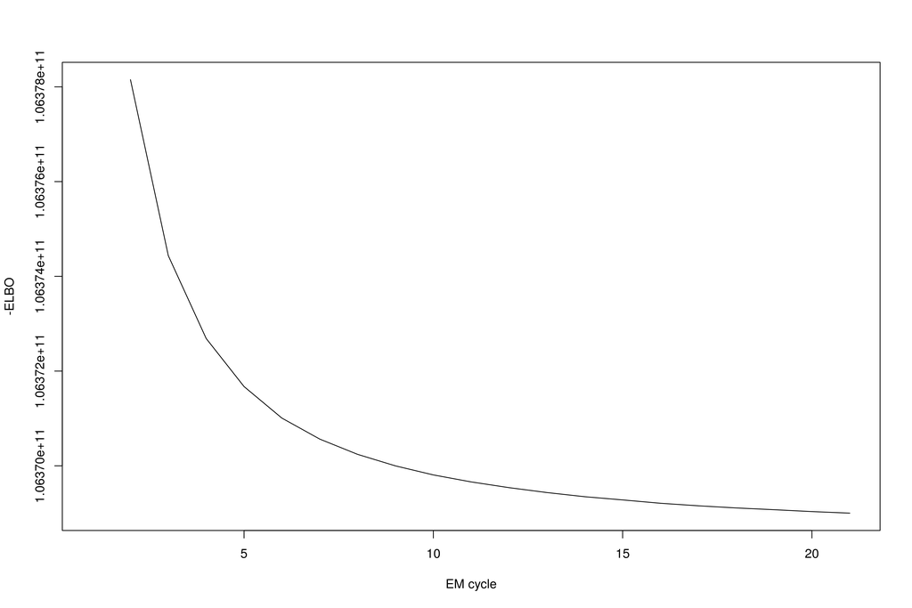

```r
plot(ebd.res$elbo, xlab="EM cycle", ylab="-ELBO", type="l")
```

To run additional EM cycles, do the following. This will start additional EM cycles by initiating starting points from the previous EM.

```r
ebd.res.2  <- learn.embedding(bp = bp.res,
                                  cycle = 10,
                                  EM.res = ebd.res,
                                  compute.elbo = T)
```

[output not shown]

[output cut: 68 more lines]

[output not shown]

- Let’s check the progress again

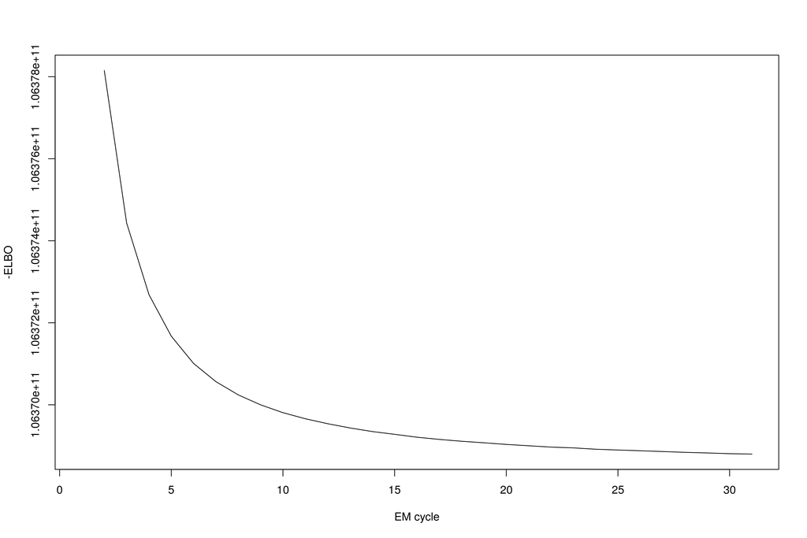

```r
plot(c(ebd.res$elbo, ebd.res.2$elbo[-1]), xlab="EM cycle", ylab="-ELBO", type="l")
```

In cases where users have their own priors about malignant gene programs, e.g., those derived from developmental programs or other biological processes of interest, they may run embedding learning using a user-defined `eta_prior`.

```r
#Not run
ebd.res.myEta  <- learn.embedding(bp = bp.res,
                                  eta_prior = my.eta, # A user supplied K-by-G matrix, at a raw count (non-log) scale.
                                  cycle = 50,
                                  compute.elbo = T)
```

# Downstream analysis

Potential downstream analysis can be performed using eta and omega are: * Clustering bulk samples by omega * Survival analysis and correlation with other clinical covariates using omega. * Correlation analysis between omega and theta_env (cell type fraction of non-malignant cells). * Gene set enrichment analysis for eta (See BayesPrism paper for details). * Select representative samples for each malignant program for downstream analysis, such as differential gene expression (See BayesPrism paper for details). * Deconvolve other bulk datasets using a reference GEP constructed by concatenating `eta_post` and `psi_env`.